# The Cost of Coal production in Pennsylvania on Community Health

https://github.com/arielocallaghan/V2_Cipparone_Niva_OCallaghan_EDA_Finalproject

Hugh Cipparone, Katryna Niva and Ariel O’Callaghan

# Reference for rmd file report

#**Introduction**

Coal-fired power plants have well-documented negative impacts on community health. (Mueller, 2022). The impact of coal mining, however, has been less closely examined. Mining activities release coal dust, ashes, metals, and aromatic hydrocarbons into the air, which can be a health hazard for workers. This can lead to elevated levels of silicon and aluminum in the body (G. leno-Meija et al, 2014). In addition, research studies have shown that coal mine workers have health effects such as black lung disease(Gasparotto, 2021).

The impact of coal production on community health is particularly important for the state of Pennsylvania, the country’s fourth coal producer. Pennsylvania has a long history of coal production, starting in the 1700s(PA DEQ). This coal production drove population growth and infrastructure throughout the state. Coal also drove Pennsylvania’s successful steel industry. Today, however, these counties have been largely abandoned by offshoring of industrial production, leaving much of Pennsylvania in the ‘rust belt’ - the swath of America once driven by manufacturing but now reliant on dwindling economic resources and home to increasing numbers of community health challenges.

This study examines the impacts of historical coal mining on community health in Pennsylvania. We more specifically examine both the impact of total coal production and the impact of temporal distance from peak coal production on county-level health outcomes in the state. By understanding the influence of coal mining on community health, we hope to be able to more effectively target community health interventions to counties most in need.

We examine this question through the use of four distinct county-level datasets: coal production data from the U.S. Energy Informational Administration (USIEA), census data from the American Community Survey (ACS), county health rankings data from the University of Wisconsin’s Community Health Rankings and Roadmap program, and Water quality data from the Water Quality Portal, a partnership between United States Geological Survey and the Environmental Protection Agency. These datasets collectively covered a broad enough time series to observe impacts in coal production over time. All focus on the state of Pennsylvania.

# Rationale and Research Questions

1. Has coal production impacted local community health in Pennsylvania?
2. How do the demographics of Pennsylvania counties vary, and how are those demographics associated with community health?
3. How do coal production and community health vary over time? Are they linked temporally or spatially?

**Dataset Information**

A summary of the four datasets and the individual data wrangling process is described below.

##The Coal Mining Dataset Our coal mining dataset provides data on annual coal production by Pennsylvania county. These data were downloaded from the U.S. Energy Information Administration website (https://www.eia.gov/coal/data.php) and cover the years from 1983 until 2021. The data was submitted across the united states by each individual mining operation and includes extensive information from the union the mine is organized under to the number of employees. It is submitted through the annual survey of coal production and communication, a mandated survey.

The wrangling process can be seen step by step below, but a summary is as follows: The coal data for each individual year was uploaded using the read.csv function. Then, the class of different columns were adjusted so that they were consistent across years and could be merged. At this point, they were merged with the full_join command such that one dataframe was formed. This new dataset was then filtered to only include data from Pennsylvania and then slimmed to only include the columns of interest (county, year, status, and production in tons). At this point, we needed to merge the columns where multiple mines were operating within a single county. This was done by converting the production to class integer, grouping by county and year, and summing the coal production within those groups. The weighted average year of coal production for each county was then calculated by summing the product of coal produced and year for each year and dividing by the total sum of coal production within each county. Finally, a column expressing the sum of coal production across all years for each county was added. At this point, this more refined dataset was saved to the processed data folder for future analysis.

###Coal Wrangling Code

```r
# inital uploading of all the coal data for each distinct year -- this
# could not be expedited with data stripping because there were separate
# links to downloaded spreadsheets instead of links to another website
coal1983 <- read.csv("./RawData/coalpublic1983.csv", stringsAsFactors = TRUE)
coal1984 <- read.csv("./RawData/coalpublic1984.csv", stringsAsFactors = TRUE)
coal1985 <- read.csv("./RawData/coalpublic1985.csv", stringsAsFactors = TRUE)
coal1986 <- read.csv("./RawData/coalpublic1986.csv", stringsAsFactors = TRUE)
coal1987 <- read.csv("./RawData/coalpublic1987.csv", stringsAsFactors = TRUE)
coal1988 <- read.csv("./RawData/coalpublic1988.csv", stringsAsFactors = TRUE)
coal1989 <- read.csv("./RawData/coalpublic1989.csv", stringsAsFactors = TRUE)
coal1990 <- read.csv("./RawData/coalpublic1990.csv", stringsAsFactors = TRUE)
coal1991 <- read.csv("./RawData/coalpublic1991.csv", stringsAsFactors = TRUE)
coal1992 <- read.csv("./RawData/coalpublic1992.csv", stringsAsFactors = TRUE)
coal1993 <- read.csv("./RawData/coalpublic1993.csv", stringsAsFactors = TRUE)
coal1994 <- read.csv("./RawData/coalpublic1994.csv", stringsAsFactors = TRUE)
coal1995 <- read.csv("./RawData/coalpublic1995.csv", stringsAsFactors = TRUE)
coal1996 <- read.csv("./RawData/coalpublic1996.csv", stringsAsFactors = TRUE)
coal1997 <- read.csv("./RawData/coalpublic1997.csv", stringsAsFactors = TRUE)
coal1998 <- read.csv("./RawData/coalpublic1998.csv", stringsAsFactors = TRUE)
coal1999 <- read.csv("./RawData/coalpublic1999.csv", stringsAsFactors = TRUE)
coal2000 <- read.csv("./RawData/coalpublic2000.csv", stringsAsFactors = TRUE)
coal2001 <- read.csv("./RawData/coalpublic2001.csv", stringsAsFactors = TRUE)
coal2002 <- read.csv("./RawData/coalpublic2002.csv", stringsAsFactors = TRUE)
coal2003 <- read.csv("./RawData/coalpublic2003.csv", stringsAsFactors = TRUE)
coal2004 <- read.csv("./RawData/coalpublic2004.csv", stringsAsFactors = TRUE)
coal2005 <- read.csv("./RawData/coalpublic2005.csv", stringsAsFactors = TRUE)
coal2006 <- read.csv("./RawData/coalpublic2006.csv", stringsAsFactors = TRUE)
coal2007 <- read.csv("./RawData/coalpublic2007.csv", stringsAsFactors = TRUE)
coal2008 <- read.csv("./RawData/coalpublic2008.csv", stringsAsFactors = TRUE)
coal2009 <- read.csv("./RawData/coalpublic2009.csv", stringsAsFactors = TRUE)
coal2010 <- read.csv("./RawData/coalpublic2010.csv", stringsAsFactors = TRUE)
coal2011 <- read.csv("./RawData/coalpublic2011.csv", stringsAsFactors = TRUE)
coal2012 <- read.csv("./RawData/coalpublic2012.csv", stringsAsFactors = TRUE)
coal2013 <- read.csv("./RawData/coalpublic2013.csv", stringsAsFactors = TRUE)
coal2014 <- read.csv("./RawData/coalpublic2014.csv", stringsAsFactors = TRUE)
coal2015 <- read.csv("./RawData/coalpublic2015.csv", stringsAsFactors = TRUE)
coal2016 <- read.csv("./RawData/coalpublic2016.csv", stringsAsFactors = TRUE)
coal2017 <- read.csv("./RawData/coalpublic2017.csv", stringsAsFactors = TRUE)
coal2018 <- read.csv("./RawData/coalpublic2018.csv", stringsAsFactors = TRUE)
coal2019 <- read.csv("./RawData/coalpublic2019.csv", stringsAsFactors = TRUE)
coal2020 <- read.csv("./RawData/coalpublic2020.csv", stringsAsFactors = TRUE)
coal2021 <- read.csv("./RawData/coalpublic2021.csv", stringsAsFactors = TRUE)

# inconsistencies in the class of certain columns needed to be resolved in
# order for the datasets to be properly merged together
coal1996$MSHA.ID <- as.factor(coal1996$MSHA.ID)
coal1997$MSHA.ID <- as.factor(coal1997$MSHA.ID)
coal1998$MSHA.ID <- as.factor(coal1998$MSHA.ID)
coal1999$MSHA.ID <- as.factor(coal1999$MSHA.ID)
coal2000$MSHA.ID <- as.factor(coal2000$MSHA.ID)
coal2001$MSHA.ID <- as.factor(coal2001$MSHA.ID)
coal2002$MSHA.ID <- as.factor(coal2002$MSHA.ID)
coal2003$MSHA.ID <- as.factor(coal2003$MSHA.ID)
coal2004$MSHA.ID <- as.factor(coal2004$MSHA.ID)
coal2005$MSHA.ID <- as.factor(coal2005$MSHA.ID)
coal2006$MSHA.ID <- as.factor(coal2006$MSHA.ID)
coal2007$MSHA.ID <- as.factor(coal2007$MSHA.ID)
coal2008$MSHA.ID <- as.factor(coal2008$MSHA.ID)
coal2009$MSHA.ID <- as.factor(coal2009$MSHA.ID)
coal2010$MSHA.ID <- as.factor(coal2010$MSHA.ID)
coal2011$MSHA.ID <- as.factor(coal2011$MSHA.ID)
coal2012$MSHA.ID <- as.factor(coal2012$MSHA.ID)
coal2013$MSHA.ID <- as.factor(coal2013$MSHA.ID)
coal2014$MSHA.ID <- as.factor(coal2014$MSHA.ID)
coal2015$MSHA.ID <- as.factor(coal2015$MSHA.ID)
coal2016$MSHA.ID <- as.factor(coal2016$MSHA.ID)
coal2017$MSHA.ID <- as.factor(coal2017$MSHA.ID)
coal2018$MSHA.ID <- as.factor(coal2018$MSHA.ID)
coal2019$MSHA.ID <- as.factor(coal2019$MSHA.ID)
coal2020$MSHA.ID <- as.factor(coal2020$MSHA.ID)
coal2021$MSHA.ID <- as.factor(coal2021$MSHA.ID)
coal2002$Average.Employees <- as.factor(coal2002$Average.Employees)
coal2003$Average.Employees <- as.factor(coal2003$Average.Employees)
coal2004$Average.Employees <- as.factor(coal2004$Average.Employees)
coal2005$Average.Employees <- as.factor(coal2005$Average.Employees)
coal2006$Average.Employees <- as.factor(coal2006$Average.Employees)
coal2007$Average.Employees <- as.factor(coal2007$Average.Employees)
coal2008$Average.Employees <- as.factor(coal2008$Average.Employees)
coal2009$Average.Employees <- as.factor(coal2009$Average.Employees)
coal2010$Average.Employees <- as.factor(coal2010$Average.Employees)
coal2011$Average.Employees <- as.factor(coal2011$Average.Employees)
coal2012$Average.Employees <- as.factor(coal2012$Average.Employees)
coal2013$Average.Employees <- as.factor(coal2013$Average.Employees)
coal2014$Average.Employees <- as.factor(coal2014$Average.Employees)
coal2015$Average.Employees <- as.factor(coal2015$Average.Employees)
coal2016$Average.Employees <- as.factor(coal2016$Average.Employees)
coal2017$Average.Employees <- as.factor(coal2017$Average.Employees)
coal2018$Average.Employees <- as.factor(coal2018$Average.Employees)
coal2019$Average.Employees <- as.factor(coal2019$Average.Employees)
coal2020$Average.Employees <- as.factor(coal2020$Average.Employees)
coal2021$Average.Employees <- as.factor(coal2021$Average.Employees)

# The datasets from each year were then merged together into one combined
# dataset
AllCoal <- full_join(coal1983, coal1984)
AllCoal <- full_join(AllCoal, coal1985)
AllCoal <- full_join(AllCoal, coal1986)
AllCoal <- full_join(AllCoal, coal1987)
AllCoal <- full_join(AllCoal, coal1988)
AllCoal <- full_join(AllCoal, coal1989)
AllCoal <- full_join(AllCoal, coal1990)
AllCoal <- full_join(AllCoal, coal1991)
AllCoal <- full_join(AllCoal, coal1992)
AllCoal <- full_join(AllCoal, coal1993)
AllCoal <- full_join(AllCoal, coal1994)
AllCoal <- full_join(AllCoal, coal1995)
AllCoal <- full_join(AllCoal, coal1996)
AllCoal <- full_join(AllCoal, coal1997)
AllCoal <- full_join(AllCoal, coal1998)
AllCoal <- full_join(AllCoal, coal1999)
AllCoal <- full_join(AllCoal, coal2000)
AllCoal <- full_join(AllCoal, coal2001)
AllCoal <- full_join(AllCoal, coal2002)
AllCoal <- full_join(AllCoal, coal2003)
AllCoal <- full_join(AllCoal, coal2004)
AllCoal <- full_join(AllCoal, coal2005)
AllCoal <- full_join(AllCoal, coal2006)
AllCoal <- full_join(AllCoal, coal2007)
AllCoal <- full_join(AllCoal, coal2008)
AllCoal <- full_join(AllCoal, coal2009)
AllCoal <- full_join(AllCoal, coal2010)
AllCoal <- full_join(AllCoal, coal2011)
AllCoal <- full_join(AllCoal, coal2012)
AllCoal <- full_join(AllCoal, coal2013)
AllCoal <- full_join(AllCoal, coal2014)
AllCoal <- full_join(AllCoal, coal2015)
AllCoal <- full_join(AllCoal, coal2016)
AllCoal <- full_join(AllCoal, coal2017)
AllCoal <- full_join(AllCoal, coal2018)
AllCoal <- full_join(AllCoal, coal2019)
AllCoal <- full_join(AllCoal, coal2020)
AllCoal <- full_join(AllCoal, coal2021)

# This combined dataset was then filtered so that it only included data
# for the state of Pennsylvania as that is the focus of this inquiry
AllCoal <- filter(AllCoal, Mine.State %in% c("Pennsylvania (Bituminous)", "Pennsylvania (Anthracite)"))

# This data was then slimmed down to the necessary data and the columns
# were appropriately titled
AllCoalSlim <- data_frame(AllCoal$Year, AllCoal$Mine.County, AllCoal$Mine.Status,
    AllCoal$Production..short.tons.) %>%
    rename(Year = "AllCoal$Year", County = "AllCoal$Mine.County", Status = "AllCoal$Mine.Status",
        `Production(tons)` = "AllCoal$Production..short.tons.")

# The coal production was then converted to class integer so that
# different mines from the same county can be summed together
AllCoalSlim$`Production(tons)` <- as.integer(AllCoalSlim$`Production(tons)`)

# This summation then occured so that there is one sum coal production
# value for each county each year
aggCoalSlim <- AllCoalSlim %>%
    group_by(County, Year) %>%
    summarise(sum.coal.production = sum(`Production(tons)`), .groups = "drop")

# A new column that dictated the weighted average year of production was
# then calculated in order to have another metric for understanding when
# the majority of the coal production was happening and what regulations
# may have been in place at that point
NewCoalSlim <- aggCoalSlim %>%
    pivot_wider(names_from = Year, values_from = sum.coal.production)

NewCoalSlim[is.na(NewCoalSlim)] <- 0

NewCoalSlim <- NewCoalSlim %>%
    mutate(Year.Max.Production = (((1983 * `1983`) + (1984 * `1984`) + (1985 *
        `1985`) + (1986 * `1986`) + (1987 * `1987`) + (1988 * `1988`) + (1989 *
        `1989`) + (1990 * `1990`) + (1991 * `1991`) + (1992 * `1992`) + (1993 *
        `1993`) + (1994 * `1994`) + (1995 * `1995`) + (1996 * `1996`) + (1997 *
        `1997`) + (1998 * `1998`) + (1999 * `1999`) + (2000 * `2000`) + (2001 *
        `2001`) + (2002 * `2002`) + (2003 * `2003`) + (2004 * `2004`) + (2005 *
        `2005`) + (2006 * `2006`) + (2007 * `2007`) + (2008 * `2008`) + (2009 *
        `2009`) + (2010 * `2010`) + (2011 * `2011`) + (2012 * `2012`) + (2013 *
        `2013`) + (2014 * `2014`) + (2015 * `2015`) + (2016 * `2016`) + (2017 *
        `2017`) + (2018 * `2018`) + (2019 * `2019`) + (2020 * `2020`) + (2021 *
        `2021`))/(`1983` + `1984` + `1985` + `1986` + `1987` + `1988` + `1989` +
        `1990` + `1991` + `1992` + `1993` + `1994` + `1995` + `1996` + `1997` +
        `1998` + `1999` + `2000` + `2001` + `2002` + `2003` + `2004` + `2005` +
        `2006` + `2007` + `2008` + `2009` + `2010` + `2011` + `2012` + `2013` +
        `2014` + `2015` + `2016` + `2017` + `2018` + `2019` + `2020` + `2021`)))

# An additional column is then added to know the total coal production
# across all years in each county
NewCoalSlim <- NewCoalSlim %>%
    mutate(sum.coal.prod = (`1983` + `1984` + `1985` + `1986` + `1987` + `1988` +
        `1989` + `1990` + `1991` + `1992` + `1993` + `1994` + `1995` + `1996` +
        `1997` + `1998` + `1999` + `2000` + `2001` + `2002` + `2003` + `2004` +
        `2005` + `2006` + `2007` + `2008` + `2009` + `2010` + `2011` + `2012` +
        `2013` + `2014` + `2015` + `2016` + `2017` + `2018` + `2019` + `2020` +
        `2021`))

# This new metric was then merged with the previous data and then
# appropriately titled
aggCoalSlim <- left_join(aggCoalSlim, NewCoalSlim, by = "County")

aggCoalSlim2 <- data_frame(aggCoalSlim$County, aggCoalSlim$Year, aggCoalSlim$sum.coal.production,
    aggCoalSlim$Year.Max.Production, aggCoalSlim$sum.coal.prod) %>%
    rename(Year = "aggCoalSlim$Year", County = "aggCoalSlim$County", coal.prod.by.year = "aggCoalSlim$sum.coal.production",
        year.peak.prod = "aggCoalSlim$Year.Max.Production", sum.coal.prod = "aggCoalSlim$sum.coal.prod")

# We now have a core dataset that can be uploaded to the processed data
# folder for use in the analysis portion. This dataset has the coal
# production per county per year as well as the summed total coal
# production and the weighted average year of production for each county
write.csv(aggCoalSlim, file = "./ProcessedData/aggCoalData.csv")
```

##Community Health Indicators

Community Health data was pulled from Community Health Rankings and Roadmap, a program of the University of Wisconsin Population Health Institute. This health rankings model was developed by the University and aims to represent how healthy a county is. And this dataset contains various indicators that have been composited into a few different summary variables. These composite variables include Health Outcomes, Health factors.

Health outcomes represent the county’s level of health. This level of health is calculated by classifying a variety of health outcomes - such as morbidity, life expectancy, birth weight, premature death etc. - into ‘length of life’ and ‘quality of life’ groupings. These groupings are then aggregated into a single ‘health outcomes’ score for the county in the given year. Health factors in contrast produce a ranking based on variables which determine the outcomes listed above, such as access to clinical care or socioeconomic variables. You can learn more about the halth ranking model at:(https://www.countyhealthrankings.org/explore-health-rankings/county-health-rankings-model). The scores from both health outcomes and health factors are output as either ranks. A rank of 1 indicates the halthiest county with decreasing health as the number increases. The Z scores provide a continuous variable that represents the distance of the given county from the mean health outcome/factor value for all of counties. A decreasing z-score indicates improving health of the county.

The datasets for Pennsylvania were downloaded from the community Health Rankings website for years 2010-2020. The data set concists of one value for each indicator by county per year. Each individual year was downloaded and then combined through the rbind function in R. Only the columns of interest were selected to create a health data frame for further analysis. The classification of each column was changed to allow for plotting and other visual representations. The wrangled health data frame includes health outcomes Z score, health outcomes rank, health factors z score, and health factors rank by county from 2010-2020 by county. This data frame is saved in the processed data folder.

###Community Health Data Wrangling Code

```r
# raw data import individual csv files
# https://www.countyhealthrankings.org/


health2010 <- read.csv("./RawData/2010health.csv", stringsAsFactors = TRUE)
health2011 <- read.csv("./RawData/2011health.csv", stringsAsFactors = TRUE)
health2012 <- read.csv("./RawData/2012health.csv", stringsAsFactors = TRUE)
health2013 <- read.csv("./RawData/2013health.csv", stringsAsFactors = TRUE)
health2014 <- read.csv("./RawData/2014health.csv", stringsAsFactors = TRUE)
health2015 <- read.csv("./RawData/2015health.csv", stringsAsFactors = TRUE)
health2016 <- read.csv("./RawData/2016health.csv", stringsAsFactors = TRUE)
health2017 <- read.csv("./RawData/2017health.csv", stringsAsFactors = TRUE)
health2018 <- read.csv("./RawData/2018health.csv", stringsAsFactors = TRUE)
health2019 <- read.csv("./RawData/2019health.csv", stringsAsFactors = TRUE)
health2020 <- read.csv("./RawData/2020health.csv", stringsAsFactors = TRUE)

# combine individual csv 2010-2020 into one file
health.all <- rbind(health2010, health2011, health2012, health2013, health2014,
    health2015, health2016, health2017, health2018, health2019, health2020)

# create new csv file with all years 2010-2020 combined
write.csv(health.all, row.names = FALSE, file = "./RawData/healthdata.combine.csv")

# Creating data frame to merge with out data. Filtering out only needed
# columns Create csv file in processed data folder
Healthdf <- select(health.all, County:year)
write.csv(Healthdf, row.names = FALSE, file = "./ProcessedData/healthdf.csv")
```

A spatial shapefile by county was also utilized to display this information. This shapefile developed by the U.S. Census is their cartographic boundary shapefile from 2020. This dataset includes the entire United States, so the state of Pennsylvania was filtered out to be combined with the health data frame. This allows community health indicators to be visualized spatially. To compare coal and non coal poducing counties, an additonal dataframe was created that filtered out only coal producing counites. Below is a summary tables capturing important variables in the health data frame.

###Spatial Wrangling Code

```r
# check colors for graphs par(mar=c(3,4,2,2)) display.brewer.all()

# Disable on-the-fly projections - code from lab sheet
sf::sf_use_s2(FALSE)
```

```
## Spherical geometry (s2) switched off
```

```r
# read in spatial data frame and filter for Pennsylvania

counties_sf <- st_read("./RawData/cb_2018_us_county_20m.shp") %>%
    filter(STATEFP == 42)  #42|PA|Pennsylvania|01779798
# check data frame information colnames(counties_sf) st_crs(counties_sf)
# nrow(counties_sf)

# Reveal the extent of this dataset via the st_bbox() function
st_bbox(counties_sf)
```

```
##      xmin      ymin      xmax      ymax
## -80.51989  39.72006 -74.69491  42.26986
```

```r
# View the data
head(counties_sf)
```

|  | STATEFP | COUNTYFP | COUNTYNS | AFFGEOID | GEOID | NAME | LSAD | ALAND | AWATER | geometry |
| --- | --- | --- | --- | --- | --- | --- | --- | --- | --- | --- |
| 1 | 42 | 113 | 01213687 | 0500000US42113 | 42113 | Sullivan | 06 | 1165338428 | 6617028 |  |
| 2 | 42 | 015 | 01213660 | 0500000US42015 | 42015 | Bradford | 06 | 2971797231 | 35229170 |  |
| 3 | 42 | 099 | 01213682 | 0500000US42099 | 42099 | Perry | 06 | 1428244417 | 10589676 |  |
| 4 | 42 | 035 | 01214721 | 0500000US42035 | 42035 | Clinton | 06 | 2299868396 | 23178635 |  |
| 5 | 42 | 075 | 01214034 | 0500000US42075 | 42075 | Lebanon | 06 | 937071896 | 1799189 |  |
| 6 | 42 | 007 | 01214112 | 0500000US42007 | 42007 | Beaver | 06 | 1125904407 | 24162728 |  |

```r
# Plot the county data, colored by area of land in each county
# mapView(counties_sf, zcol = 'ALAND') #check plot with land but not
# needed for report

# read in health data frame to join with spatial datframe
healthdf <- read.csv("./ProcessedData/healthdf.csv", stringsAsFactors = TRUE)

counties_sf$NAME <- as.character(counties_sf$NAME)
class(counties_sf$NAME)
```

```
## [1] "character"
```

```r
healthdf$County <- as.character(healthdf$County)
class(healthdf$County)
```

```
## [1] "character"
```

```r
(healthdf)
```

| County | Health.Outcomes.Z.Score | Health.Outcomes.Rank | Health.Factors.Z.Score | Health.Factors.Rank | year |
| --- | --- | --- | --- | --- | --- |
| Adams | -0.34 | 21 | -0.59 | 7 | 2010 |
| Allegheny | 0.32 | 49 | -0.04 | 26 | 2010 |
| Armstrong | 0.74 | 58 | 0.32 | 55 | 2010 |
| Beaver | 0.19 | 44 | -0.08 | 25 | 2010 |
| Bedford | -0.06 | 31 | 0.07 | 35 | 2010 |
| Berks | -0.49 | 16 | -0.11 | 23 | 2010 |
| Blair | 0.95 | 63 | 0.05 | 33 | 2010 |
| Bradford | -0.64 | 12 | -0.11 | 22 | 2010 |
| Bucks | -0.94 | 7 | -0.94 | 3 | 2010 |
| Butler | -0.71 | 11 | -0.66 | 6 | 2010 |

[output cut: 727 more lines]

```r
# counties_sf<- counties_sf %>% rename(NAME== County)


# join data sets together
counties_sf_join <- merge(x = counties_sf, y = healthdf, by.x = "NAME", by.y = "County")


coal <- read.csv("./ProcessedData/Coal.Clean.csv", stringsAsFactors = TRUE)
# list(coal$County)

# Subset coal counties but not working
coal.filter <- counties_sf_join %>%
    filter(NAME %in% c("Armstrong", "Beaver", "Bedford", "Blair", "Butler",
        "Berks", "Carbon", "Dauphin", "Fayette", "Greene", "Allegheny", "Blair",
        "Cameron", "Cambria", "Centre", "Clarion", "Clearfield", "Clinton",
        "Columbia", "Elk", "Huntingdon", "Indiana", "Jefferson", "Lackawanna",
        "Lawrence", "Luzerne", "Lycoming", "Mercer", "Monongalia", "Montgomery",
        "Northumberland", "Somerset", "Schuylkill", "Sullivan", "Tioga", "Westmoreland",
        "Washington", "Venango", "Fulton"))

# Visualizations
class(counties_sf_join$NAME)
```

```
## [1] "character"
```

```r
NCOL(counties_sf_join$NAME)
```

```
## [1] 1
```

```r
# filter for 2019 only to plot
Health.2019 <- counties_sf_join %>%
    filter(year == 2019)


coal.2019 <- coal.filter %>%
    filter(year == 2019)


# plot 2010 Data
Health.2010 <- counties_sf_join %>%
    filter(year == 2010)

coal.2010 <- coal.filter %>%
    filter(year == 2010)
```

Summary tables describing the dimensions of the health data set are below. It should be noted that the variables are ranks and Z scores and therefore the dimensions of the dataset is simple.

###Community Health Outcome Summary Table

Health Indicators Outcomes Summary Table

[output not shown]

###Community Health Z Score Summary Table

Health Indicators Z Score Summary Table

[output not shown]

##American Community Survey The third dataset - the ACS dataset - comes from the American Community Survey. This survey has been run by the US Census Bureau once a year since 2005, and provides information on a wide range of socioeconomic variables at multiple spatial scales, including the county level. We chose to use the single-year estimates (other options are estimates for socioeconomic variables extending over five or ten year periods) to match our single year data for coal production over time. You can learn more at: https://www.census.gov/programs-surveys/acs

We collected these data through the tidycensus R package, which pulls the data using an Application Programming Interface (API) (https://walker-data.com/tidycensus/). We specifically pulled data on the county level within Pennsylvania for five variables: total population, total white population, median income, median age and population with a bachelor’s degree. We selected these five variables due to the well documented importance of income, education, and age on human health (https://pubmed.ncbi.nlm.nih.gov/8820314/, https://www.cdc.gov/minorityhealth/racism-disparities/index.html) and therefore their potential role as confounding variables in the relationship between coal production and community health.

We wrangled these data using the tidyverse package to capture the percentage of the county which was white-identifying - rather than the total population of white people - and the percentage of the county with a bachelor’s degree - rather than the total population. Each of these modifications permitted us to compare race and education rates in counties with different total populations. We also removed any counties which reported populations which had zero white people, assuming that these data points could not be accurate in the majority-white US. We only used 2019 socioeconomic variables in the multiple linear regression at the heart of this project.

###ACS Summary Table The summary statistics table below captures a number of important characteristics of the collected variables from the year 2019:

Table 1: County-level Summary Statistics of Socioeconomic Variables in Pennsylvania

| Variable | Observations | Median | Mean | SD | Range | Minimum | Maximum |
| --- | --- | --- | --- | --- | --- | --- | --- |
| X | 40 | 20.50 | 20.50 | 11.69 | 39.00 | 1.00 | 40.00 |
| Total Population | 40 | 167,100.00 | 296,177.88 | 316,664.55 | 1,519,882.00 | 64,182.00 | 1,584,064.00 |
| Median Age | 40 | 42.30 | 42.47 | 3.16 | 14.20 | 33.40 | 47.60 |
| Median Income (USD) | 40 | 30,676.00 | 31,922.28 | 5,099.44 | 21,142.00 | 25,728.00 | 46,870.00 |
| % White-Identifying | 40 | 87.48 | 80.07 | 25.28 | 95.94 | 0.00 | 95.94 |
| % with Bachelor's Degree | 40 | 11.52 | 12.17 | 3.50 | 14.12 | 7.78 | 21.90 |
| year | 40 | 2,019.00 | 2,019.00 | 0.00 | 0.00 | 2,019.00 | 2,019.00 |

##Combined Datasets

After collecting each of our individual datasets, we created two combined datasets - one for the multiple linear regression and another for the time series analysis examining the relationship between health outcomes and coal production over time.

We created the dataset for the multiple linear regression by creating a coal dataset for all of the coal counties with only the total production over time and the calculation of the number of years from peak production to 2019. This was grouped by county (previous calculations for these values had already occurred during initial wrangling of the coal dataset). This was then left joined to the health dataset which had been filtered to only include health values for 2019. This retained all of the counties included in the health dataset while integrating the production values for the counties which produced coal. We then imputed values of ‘0’ total coal production for the counties with NAs in that field - NAs produced by the fact that they weren’t in the coal dataset and therefore had not seen any coal production over time. We then imputed values of ‘37’ for the years from peak production to 2019, as the coal dataset ran from 1983. Thirty-seven years permitted us to use these counties in the multiple linear regression, placed these non-coal producing counties as counties with long temporal distance from the present - something you would assume would be associated with presumably healthy counties given their low coal production, gave us a value with reason - 37 years is the temporal distance from 2019 to 1982, the year before we have any data - and gave us a value that wouldn’t extensively skew the data. Finally we left joined this dataset to our ACS data, and subtracted any counties with ‘NAs’ and any counties with ’0’s for total white population, as we assumed that these data were incorrect given the racial composition of the US and the other counties (all of whose percentage of white people were around 70% with the sole exception of Philadelphia). This left us with a sample size of 37 counties. This data set is saved to the processed data folder.

We created the dataset for the time series analysis by utilizing data from the aggCoalData csv and the health.data csv previously saved and covered above. First, we read the dataframes into r. We then had to rename the year column for the health data frame so that it had the same title as the year column for the aggCoalData. At that point, we were able to merge (using the two datasets) the two data sets by county and year and select the columns necessary for the analysis (Year, county, health outcomes z score, health factors z score, and coal production). Note that this only included the counties that produced coal at some point but as we were looking for a correlation between coal production and health z scores over time, we did not need to factor in the counties with zero coal production. Also note that this dataset only covered the years from 2010 until 2020. These are the only years that the health data was available for and so the only years pertinent to include in this dataset. At this point, we had a dataframe with concurrent measures of coal production and health z scores for each coal producing county in the year span of 2010 to 2020.

##**Exploratory Analysis**

Exploratory analysis was conducted on the individual data to trends for each different data categories independently.

##Coal Production

```r
# random action just to test things
x <- 1
```

##Community Health Indicators A spatial analysis was utilized to display health outcomes rank and Z score by county for 2019 and 2010. 2010 was chosen because it is the first year of available data, and 2019 was chosen because it is the year utilized for the multilinear regression. A side-by-side map view is shown for all the health visualizations to compare all counties on the left pane with only coal-producing counties on the right pane. Rankings range from 1-67 because there are 67 counties in Pennsylvania. The dataset from EIA indicated that 37 of these 67 counties have, at some point, produced coal. These 37 counties were subset for the the comparison. Additionally, counties on the map can be hovered over to see the indicator value mapped and the specific county information. (MAY NOT WORK IN KNITTED DOCUMENT- NOT SURE)

###Figure (2019 Z score)

```r
# (Caption figure XX: Shows Z scores of health outcome data by County in
# 2019)

## Figure Caption: Coal Production plotted over time at each Pennsylvania
## county

# 2019 Z score
all.Z.2019 <- mapview(Health.2019, zcol = "Health.Outcomes.Z.Score", col.regions = brewer.pal(10,
    "OrRd"))


coal.z.2019 <- mapview(coal.2019, zcol = "Health.Outcomes.Z.Score", col.regions = brewer.pal(10,
    "OrRd"))

sync(all.Z.2019, coal.z.2019)
```

[interactive chart not shown]

This figure shows that most of the counties with a high Z score, darker orange indicating poor health, are shown on the right pannel indicating coal producing counties.. There are a few exceptions, for example, the County of Philadelphia, which also includes the City of Philadelphia, the largest city in the State of Pennsylvania (source). The other major exception is the County of Centre, the county shown middle, which had relatively low total coal production (2,543,689 tons) compared to neighboring counties.

```r
# (Caption figure XX: Health outcomes ranking by county for 2019.)

# 2019 Rank
all.rank.2019 <- mapview(Health.2019, zcol = "Health.Outcomes.Rank", col.regions = brewer.pal(20,
    "Blues"))

coal.rank.2019 <- mapview(coal.2019, zcol = "Health.Outcomes.Rank", col.regions = brewer.pal(20,
    "Blues"))

sync(all.rank.2019, coal.rank.2019)
```

[interactive chart not shown]

###2010 z score map

```r
# (Caption figure XX: Shows Z scores of health outcome by County in 2010)

# 2010 Z score
all.z.2010 <- mapview(Health.2010, zcol = "Health.Outcomes.Z.Score", col.regions = brewer.pal(5,
    "OrRd"))

coal.z.2010 <- mapview(coal.2010, zcol = "Health.Outcomes.Z.Score", col.regions = brewer.pal(5,
    "OrRd"))

# showing maps side by side
sync(all.z.2010, coal.z.2010)
```

[interactive chart not shown]

The same analysis as the maps above was conducted for the year 2010. Looking at the left pane, there is one county stands out. This county is Philadelphia, which has a Z score in 2010 of 3.43. The next highest Z score for that year is 1.21 in Greene County, a coal-producing county. This county is displayed at the bottom left on the Pennsylvania map. The scale of the right pane is slightly different due to Philadelphia County not being included. A few counties with a history of coal production have a low Z score and, therefore, better health. Centre county has the lowest Z score of -1.53, the county with the lightest orange color in the right pane. Butler county is the next healthiest with a z score of -0.71. As you can see from the visualization in this figure, most counties in 2010 with the highest z score indicating poor health are counties that have a history of local production.

###2010 rank map

```r
# (Caption figure XX: Health outcomes ranking by county in 2010.)

# 2010 Rank
all.rank.2010 <- mapview(Health.2010, zcol = "Health.Outcomes.Rank", col.regions = brewer.pal(20,
    "Blues"))

coal.rank.2010 <- mapview(coal.2010, zcol = "Health.Outcomes.Rank", col.regions = brewer.pal(20,
    "Blues"))

sync(all.rank.2010, coal.rank.2010)
```

[interactive chart not shown]

Similar patterns emerge in the 2010 ranking as they did in the 2019 map. In 2010, eight out of the 37 coal-producing counties had health rankings below 20. These are Centre, Bulter, Columbia, Indiana, Montgomery, Berks, Westmoreland, and Jefferson. Rankings of counties with the poorest health 50-67 are composed mostly of coal-producing counties except Philadelphia ranked 67, Wayne ranked 62, Forest ranked 53 and McKean ranked 50.

These maps provide a clear visualization that counties with a history of coal production counties are typically in poor health when examining these community health indicators.

##ACS

###(Graphic of median age, income, pop etc. for all PA counties)

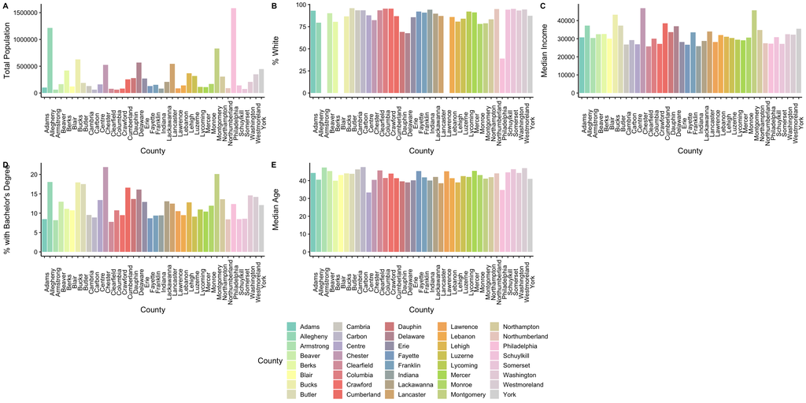

Graph depicting median age, median income, total population, percent of population with a bachelor’s degree and percent of population which is white-identifying for Pennsylvania counties in 2019. Data sourced from ACS 1-year estimates.

```r
# create large color-blind friendly color palette Define the number of
# colors you want
nb.cols <- 40
mycolors <- colorRampPalette(brewer.pal(9, "Set3"))(nb.cols)

# Create individual bar charts for the variables of interest (population,
# race, income etc.) for each of the counties

pop <- ggplot(pa.2019.clean, aes(County, totpop, fill = County)) + geom_bar(stat = "identity") +
    ylab("Total Population") + xlab("County") + theme(axis.text.x = element_text(angle = 90)) +
    scale_fill_manual(values = mycolors) + theme(legend.position = "none")

race <- ggplot(pa.2019.clean, aes(County, perc.white, fill = County)) + geom_bar(stat = "identity") +
    ylab("% White") + xlab("County") + theme(axis.text.x = element_text(angle = 90)) +
    scale_fill_manual(values = mycolors) + theme(legend.position = "none")

income <- ggplot(pa.2019.clean, aes(County, medincome, fill = County)) + geom_bar(stat = "identity") +
    ylab("Median Income") + xlab("County") + theme(axis.text.x = element_text(angle = 90)) +
    scale_fill_manual(values = mycolors) + theme(legend.position = "none")

bachdegree <- ggplot(pa.2019.clean, aes(County, perc.bachdegree, fill = County)) +
    geom_bar(stat = "identity") + ylab("% with Bachelor's Degree") + xlab("County") +
    theme(axis.text.x = element_text(angle = 90)) + scale_fill_manual(values = mycolors)

age <- ggplot(pa.2019.clean, aes(County, medage, fill = County)) + geom_bar(stat = "identity") +
    ylab("Median Age") + xlab("County") + theme(axis.text.x = element_text(angle = 90)) +
    scale_fill_manual(values = mycolors) + theme(legend.position = "none")

# Merge all of the plots into a single figure using a cowplot

ggarrange(pop, race, income, bachdegree, age, align = "hv", labels = c("A",
    "B", "C", "D", "E"), common.legend = T, legend = "bottom", nrows = 2)
```

```r
# Graphic of median age, income, pop etc. for all PA counties

# Caption: Figure ____: Graph depicting median age, median income, total
# population, percent of population with a bachelor’s degree and percent
# of population which is white-identifying for Pennsylvania counties in
# 2019. Data sourced from ACS 1-year estimates.
```

##**Analysis**

##Time Series Analysis We first examined the relationship between health outcomes and coal production between 2010 and 2020. While this permits us to investigate the relationship between our two variables of greatest interest, it is important to note that many of the contamination concerns associated with mining occur in the years following coal mining (water contamination from acid mine drainage).

####code for looking at schuylkill county with plots of coal production over health factors and coal production over health outcomes and linear regressions

```r
# code for looking at schuylkill county with plots of coal production over
# health factors and coal production over health outcomes and linear
# regressions

# Figure Caption: Synchronous plot of coal production and health factors z
# score over time in the Schuylkill county
```

[output not shown]

```r
# Figure Caption: Synchronous plot of coal production and health outcomes
# z score over time in the Schuylkill county
```

[output not shown]

###code for looking at armstrong county with plots of coal production over health factors and coal production over health outcomes and linear regressions

```r
# (code for looking at armstrong county with plots of coal production over
# health factors and coal production over health outcomes and linear
# regressions)

# Figure Caption: Synchronous plot of coal production and health factors z
# score over time in the Armstrong county
```

[output not shown]

```r
# Figure Caption: Synchronous plot of coal production and health outcomes
# z score over time in the Armstrong county
```

[output not shown]

###(code for looking at clearfield county with plots of coal production over health factors and coal production over health outcomes and linear regressions)

```r
# Figure Caption: Synchronous plot of coal production and health factors z
# score over time in the Clearfield county
```

[output not shown]

```r
# Figure Caption: Synchronous plot of coal production and health outcomes
# z score over time in the Clearfield county
```

[output not shown]

##ACS

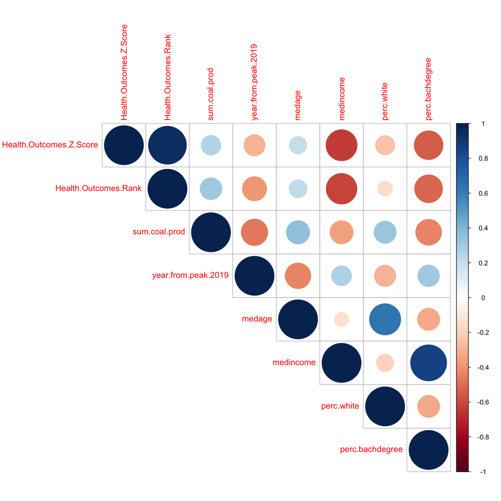

```r
# Create combined dataset with all variables linked appropriately to 2019.
# Create 'year from peak to 2019' variable

Coal_Clean <- read.csv("./ProcessedData/Coal.Clean.csv")
acs <- read.csv("./ProcessedData/acs.combined.years.csv")
health <- read.csv("./ProcessedData/healthdf.csv")

coal.sumprod <- Coal_Clean %>%
    filter(Year == 2019) %>%
    group_by(County) %>%
    summarize(year.peak.prod = mean(year.peak.prod), sum.coal.prod = mean(sum.coal.prod)) %>%
    mutate(year.from.peak.2019 = 2019 - year.peak.prod)

health.data <- health %>%
    filter(year == 2019)

health.coal <- left_join(health.data, coal.sumprod)

health.coal.impute <- health.coal %>%
    select(!year.peak.prod) %>%
    mutate_at(vars(sum.coal.prod), replace_na, "0") %>%
    mutate_at(vars(year.from.peak.2019), replace_na, "37")

acs.clean <- acs %>%
    select(!c(1:2))

health.coal.acs.impute <- left_join(health.coal.impute, acs.clean)

write.csv(health.coal.acs.impute, "./ProcessedData/health.coal.acs.impute.csv")

# re-import the data

data <- read.csv("./ProcessedData/health.coal.acs.impute.csv")

# format the data to get values that you want for the regression and
# correlation analysis - ie no NAs, no counties with 0 white people
data.edit <- data %>%
    filter(perc.white != 0) %>%
    na.omit() %>%
    select(!X)

# remove county and other non-informative (and/or categorical) variables
# to permit correlation plot
acs.health.coal.cor.edit <- data.edit %>%
    select(!c(County, totpop, totpopwhite, bachdegree, Health.Factors.Z.Score,
        Health.Factors.Rank, year)) %>%
    na.omit()

# Run correlation plot
acs.health.coal.Corr <- cor(acs.health.coal.cor.edit)
corrplot(acs.health.coal.Corr, method = "circle", type = "upper")
```